# My First Document

David Piekarski

11/30/2018

# CheatSheet

Number of hashtages representes the level of teh ehader, thus, fewer hashtags means larger font

# Level One Header

## Links

Here is a link to [Google](http://www.google.com): Names in square brackets followed by link in parentheses. You can also include the raw link by putting it between “<>” resulting in, http://www.google.com

## Emphasis

*Italics* are created by bookending a word in asterisks while **Bolds** are created by bookending a word in double asterisks. Alternately, you can use *single* or **double underscores**

If you want to show r code, without running it, put code between three backticks

```
2 + 2 =4
ggplot(data, aes(x=x, y=y)) + geom_point()
```

**Non numbered list**: each indent must be four spaces for markdown to recognize that it is a list

- Breakfast
  - food
    - eggs
    - rice
    - toast

#### Format Quotes

> this is a block quote, started with a greater than symbol

> > you can also nest a blockquote if you add five spaces after greater than, you can nest code

> ```
> 2 + 2
> ```

#### The below text is actual r code that has been run

## Insert Tables

```r
knitr::kable(head(cars),
             caption = "Head of cars dataset")
```

Head of cars dataset

| speed | dist |
| --- | --- |
| 4 | 2 |
| 4 | 10 |
| 7 | 4 |
| 7 | 22 |
| 8 | 16 |
| 9 | 10 |

## Insert an Equation using latex (identified with $$)

$$Y = \beta_0 + \beta_1x$$

## Insert Images

**you can bring in external pictures and files, just have them stored in the same location as the markdown file**

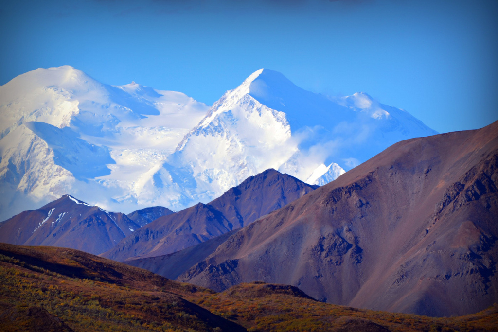

Mountains

## Footnotes:

You can provide footnotes using either inline methods (where you write teh footnotes near its location) or you can add a marker and then provide footnote text at the end of the document.